# E-Commerce Customer Data

```python
%matplotlib inline
import numpy as np
import matplotlib.pyplot as plt
import seaborn as sns; sns.set()
#from sklearn.datasets import fetch_mldata
from sklearn.decomposition import PCA
from sklearn import metrics
from sklearn.datasets import fetch_lfw_people
from sklearn.model_selection import train_test_split
import pandas as pd
from sklearn.linear_model import LogisticRegression
from sklearn.preprocessing import StandardScaler
import numpy as np
import time
import warnings
warnings.filterwarnings("ignore")
import os
from sklearn.preprocessing import LabelEncoder
from sklearn.linear_model import LinearRegression
from sklearn.model_selection import train_test_split, RandomizedSearchCV
from sklearn import metrics
```

```python
os.chdir('C:\\Users\\VGopalak\\Downloads\\46723c127bdb11eb\\dataset')
```

```python
test=pd.read_csv('test.csv')
train=pd.read_csv('train.csv')
```

```python
df=train.copy()
```

# Data Exploration

**Shape of the data**

```python
df.shape
```

```
(3837, 19)
```

- **It has 19 columns and 3837 rows.**

**Checking first 5 rows**

```python
df.head()
```

|  | sess_id | prod_class | prod_dur | is_special | date | os_class | int_brws | region | traffic_class | vis_type | is_weekend | tmp_1 | tmp_2 | tmp_3 | tmp_4 | tmp_5 | tmp_6 | tmp_7 | rev_prob |
| --- | --- | --- | --- | --- | --- | --- | --- | --- | --- | --- | --- | --- | --- | --- | --- | --- | --- | --- | --- |
| 0 | Tr-1 | 1.0 | 0.000000 | 0.0 | 21-Feb-16 | 1 | 1.0 | 1.0 | 1 | Returning_Visitor | False | 0.145833 | 0.145833 | 0.0 | 0.145833 | 0.212500 | 0.212500 | NaN | 0.350129 |
| 1 | Tr-2 | 2.0 | 64.000000 | 0.0 | 21-Feb-16 | 2 | 2.0 | 1.0 | 2 | Returning_Visitor | False | 0.145833 | 0.145833 | 0.0 | 0.145833 | 0.145833 | 0.179167 | 0.145833 | 0.270099 |
| 2 | Tr-3 | 1.0 | 0.000000 | 0.0 | 28-Feb-16 | 4 | 1.0 | 9.0 | 3 | Returning_Visitor | False | 0.145833 | 0.145833 | 0.0 | 0.145833 | 0.212500 | 0.212500 | 0.145833 | 0.455226 |
| 3 | Tr-4 | 2.0 | 2.666667 | 0.0 | 17-Feb-16 | 3 | 2.0 | 2.0 | 4 | Returning_Visitor | False | 0.145833 | 0.145833 | 0.0 | 0.145833 | 0.162500 | 0.192500 | 0.145833 | 0.127214 |
| 4 | Tr-5 | 10.0 | 627.500000 | 0.0 | 07-Feb-16 | 3 | 3.0 | 1.0 | 4 | Returning_Visitor | True | 0.145833 | 0.145833 | 0.0 | NaN | 0.152500 | 0.162500 | 0.145833 | 0.416134 |

```python
df.info()
```

```
<class 'pandas.core.frame.DataFrame'>
RangeIndex: 3837 entries, 0 to 3836
Data columns (total 19 columns):
 #   Column         Non-Null Count  Dtype
---  ------         --------------  -----
 0   sess_id        3837 non-null   object
 1   prod_class     3404 non-null   float64
 2   prod_dur       3822 non-null   float64
 3   is_special     3837 non-null   float64
 4   date           3837 non-null   object
 5   os_class       3837 non-null   int64
 6   int_brws       3668 non-null   float64
 7   region         3163 non-null   float64
 8   traffic_class  3837 non-null   int64
 9   vis_type       3837 non-null   object
 10  is_weekend     3837 non-null   bool
 11  tmp_1          3805 non-null   float64
 12  tmp_2          3285 non-null   float64
 13  tmp_3          3440 non-null   float64
 14  tmp_4          3669 non-null   float64
 15  tmp_5          3511 non-null   float64
 16  tmp_6          3830 non-null   float64
 17  tmp_7          2801 non-null   float64
 18  rev_prob       3837 non-null   float64
dtypes: bool(1), float64(13), int64(2), object(3)
memory usage: 543.5+ KB
```

- **sess_id,date and vis-type variables has object datatype.**
- **Is_weekend variable is boolean and rest of the variables has int and float as datatype**
- **Since clear description about each variable is not available, making my own assumptions on variables and using exact column names for analysis.**

**Summary**

```python
df.describe()
```

|  | prod_class | prod_dur | is_special | os_class | int_brws | region | traffic_class | tmp_1 | tmp_2 | tmp_3 | tmp_4 | tmp_5 | tmp_6 | tmp_7 | rev_prob |
| --- | --- | --- | --- | --- | --- | --- | --- | --- | --- | --- | --- | --- | --- | --- | --- |
| count | 3404.000000 | 3822.000000 | 3837.000000 | 3837.000000 | 3668.000000 | 3163.000000 | 3837.000000 | 3805.000000 | 3285.000000 | 3440.000000 | 3669.000000 | 3511.000000 | 3830.000000 | 2801.000000 | 3837.000000 |
| mean | 22.222973 | 868.644357 | 0.107323 | 2.096690 | 2.316794 | 3.026557 | 3.713839 | 0.756696 | 21.904886 | 0.388081 | 9.129725 | 0.154610 | 0.162010 | 1.697835 | 0.345618 |
| std | 27.491691 | 1222.618679 | 0.252869 | 0.780218 | 1.484938 | 2.303764 | 3.426488 | 0.957631 | 52.803386 | 1.090938 | 37.545233 | 0.018183 | 0.017839 | 5.594429 | 0.177458 |
| min | 0.000000 | 0.000000 | 0.000000 | 1.000000 | 1.000000 | 1.000000 | 1.000000 | 0.145833 | 0.145833 | 0.000000 | 0.145833 | 0.145833 | 0.145892 | 0.145833 | 0.100136 |
| 25% | 6.000000 | 137.375000 | 0.000000 | 2.000000 | 2.000000 | 1.000000 | 2.000000 | 0.145833 | 0.145833 | 0.000000 | 0.145833 | 0.145833 | 0.150595 | 0.145833 | 0.215415 |
| 50% | 14.000000 | 458.750000 | 0.000000 | 2.000000 | 2.000000 | 2.000000 | 3.000000 | 0.145833 | 0.145833 | 0.000000 | 0.145833 | 0.146287 | 0.155146 | 0.145833 | 0.323556 |
| 75% | 28.000000 | 1130.385227 | 0.000000 | 2.000000 | 2.000000 | 4.000000 | 4.000000 | 1.145833 | 22.468056 | 0.000000 | 0.145833 | 0.152500 | 0.164881 | 0.145833 | 0.434326 |
| max | 328.000000 | 13158.666670 | 1.000000 | 8.000000 | 12.000000 | 9.000000 | 20.000000 | 8.145833 | 682.557449 | 14.000000 | 593.201389 | 0.212500 | 0.212500 | 87.309595 | 0.999118 |

- **Prod_class: Mean is greater than median. There might be little positive skewness and there exists extreme value as well**
- **Prod_dur: Mean is greater than median. This is due too extreme values. There is huge spike in 75% to max value.**
- **Is_special: 75 % of data does not have special customer.**
- **os_class,int_bws: Mean and median nearly equal . Both has extreme values.**
- **Region: 75% of customers comes under region 4.**
- **Traffic_class: 75% of customers comes under class 4**
- **Tmp variables: All tmp variables has extreme values. tmp_2,tmp_4,tmp_7 has huge extrems.**
- **Rev_prob: Mean is slightly higher than median. This is dud to little spike towards the end.**

# Data Cleansing and EDA

**Missing Value check.**

```python
df.isnull().sum()
```

```
sess_id             0
prod_class        433
prod_dur           15
is_special          0
date                0
os_class            0
int_brws          169
region            674
traffic_class       0
vis_type            0
is_weekend          0
tmp_1              32
tmp_2             552
tmp_3             397
tmp_4             168
tmp_5             326
tmp_6               7
tmp_7            1036
rev_prob            0
dtype: int64
```

**Data has few missing values in many columns for continuous variables .Since we have many extreme values imputing all missing values with median.**

```python
null_col=[]
for i,j in enumerate(df.columns):
    if df.isnull().sum()[i]>0:
        df[j].fillna(df[j].median(),inplace=True)
        null_col.append(j)
    else:
        pass
#print(null_col)
```

```python
df.isnull().sum()
```

```
sess_id          0
prod_class       0
prod_dur         0
is_special       0
date             0
os_class         0
int_brws         0
region           0
traffic_class    0
vis_type         0
is_weekend       0
tmp_1            0
tmp_2            0
tmp_3            0
tmp_4            0
tmp_5            0
tmp_6            0
tmp_7            0
rev_prob         0
dtype: int64
```

**All Missing values are imputed with median.**

# **Sess_id**

```python
df['sess_id'].nunique()
```

```
3837
```

**All Records are unique so making it as index.**

```python
df.set_index(['sess_id'],inplace=True)
```

```python
df.head()
```

| sess_id | prod_class | prod_dur | is_special | date | os_class | int_brws | region | traffic_class | vis_type | is_weekend | tmp_1 | tmp_2 | tmp_3 | tmp_4 | tmp_5 | tmp_6 | tmp_7 | rev_prob |
| --- | --- | --- | --- | --- | --- | --- | --- | --- | --- | --- | --- | --- | --- | --- | --- | --- | --- | --- |
| Tr-1 | 1.0 | 0.000000 | 0.0 | 21-Feb-16 | 1 | 1.0 | 1.0 | 1 | Returning_Visitor | False | 0.145833 | 0.145833 | 0.0 | 0.145833 | 0.212500 | 0.212500 | 0.145833 | 0.350129 |
| Tr-2 | 2.0 | 64.000000 | 0.0 | 21-Feb-16 | 2 | 2.0 | 1.0 | 2 | Returning_Visitor | False | 0.145833 | 0.145833 | 0.0 | 0.145833 | 0.145833 | 0.179167 | 0.145833 | 0.270099 |
| Tr-3 | 1.0 | 0.000000 | 0.0 | 28-Feb-16 | 4 | 1.0 | 9.0 | 3 | Returning_Visitor | False | 0.145833 | 0.145833 | 0.0 | 0.145833 | 0.212500 | 0.212500 | 0.145833 | 0.455226 |
| Tr-4 | 2.0 | 2.666667 | 0.0 | 17-Feb-16 | 3 | 2.0 | 2.0 | 4 | Returning_Visitor | False | 0.145833 | 0.145833 | 0.0 | 0.145833 | 0.162500 | 0.192500 | 0.145833 | 0.127214 |
| Tr-5 | 10.0 | 627.500000 | 0.0 | 07-Feb-16 | 3 | 3.0 | 1.0 | 4 | Returning_Visitor | True | 0.145833 | 0.145833 | 0.0 | 0.145833 | 0.152500 | 0.162500 | 0.145833 | 0.416134 |

# **Date**

```python
df['date']=pd.to_datetime(df['date'])
```

**Changed date column to datetime datatype**

# **Is_Special**

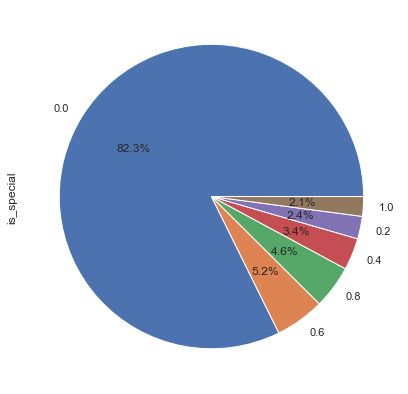

```python
plt.figure(figsize=(17,7))
df['is_special'].value_counts().plot.pie(autopct='%1.1f%%')
plt.show()
```

**Making special customer when value is greater than 0.5**

```python
df['is_special'].values[df['is_special'] > 0.5] = 1
df['is_special'].values[df['is_special'] < 0.5] = 0
```

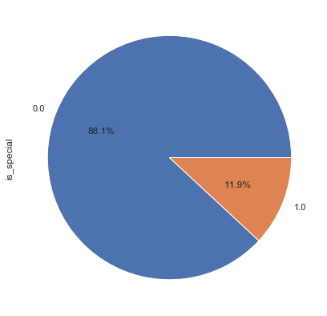

```python
plt.figure(figsize=(17,7))
df['is_special'].value_counts().plot.pie(autopct='%1.1f%%')
plt.show()
```

# **os_class**

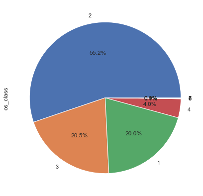

```python
plt.figure(figsize=(17,7))
df['os_class'].value_counts().plot.pie(autopct='%1.1f%%')
plt.show()
```

**Here class 4,6,7,8 does not have much records. so combining all these classes as class 3.**

```python
df['os_class'].values[df['os_class'] > 3] = 3
```

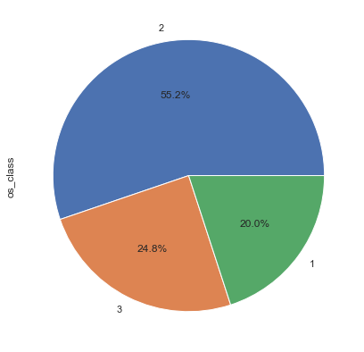

```python
plt.figure(figsize=(17,7))
df['os_class'].value_counts().plot.pie(autopct='%1.1f%%')
plt.show()
```

- **Now Distribution looks fine.**
- **55% of data belongs to class 2**

# **int_brws**

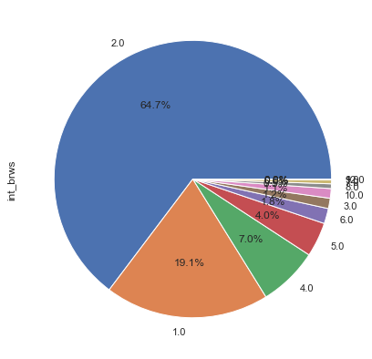

```python
plt.figure(figsize=(17,7))
df['int_brws'].value_counts().plot.pie(autopct='%1.1f%%')
plt.show()
#df['int_brws'].value_counts()
```

**Less records for values more than 2. Combining them as single bin.**

```python
df['int_brws'].values[df['int_brws'] > 2] = 3
```

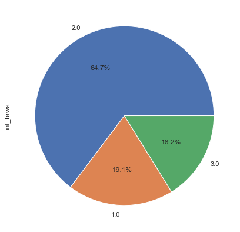

```python
plt.figure(figsize=(17,7))
df['int_brws'].value_counts().plot.pie(autopct='%1.1f%%')
plt.show()
```

- **Now Distribution looks fine.**
- **64% of data belongs to class 2**

# **traffic_class**

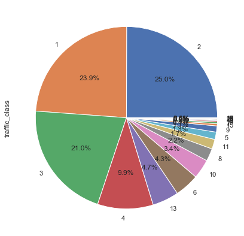

```python
plt.figure(figsize=(17,7))
df['traffic_class'].value_counts().plot.pie(autopct='%1.1f%%')
plt.show()
```

**Changing more than 3 as one class**

```python
df['traffic_class'].values[df['traffic_class'] > 3] = 4
```

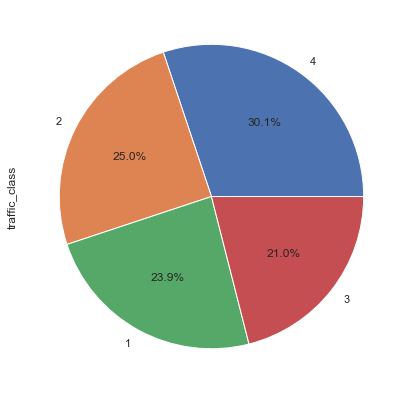

```python
plt.figure(figsize=(17,7))
df['traffic_class'].value_counts().plot.pie(autopct='%1.1f%%')
plt.show()
```

- **Now Distribution looks fine.**
- **Traffic class id equally distributed to all classes.**

# **Region**

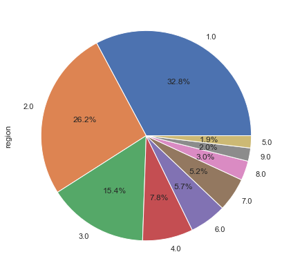

```python
plt.figure(figsize=(17,7))
df['region'].value_counts().plot.pie(autopct='%1.1f%%')
plt.show()
```

**Changing more than 3 as one class**

```python
df['region'].values[df['region'] > 3] = 4
```

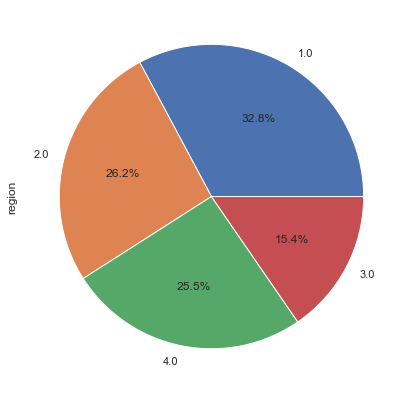

```python
plt.figure(figsize=(17,7))
df['region'].value_counts().plot.pie(autopct='%1.1f%%')
plt.show()
```

# vis_type

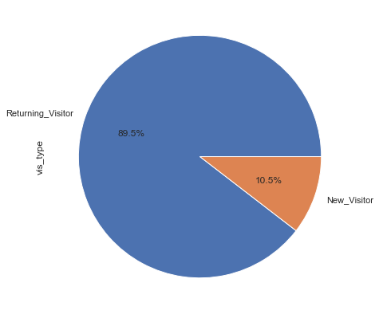

```python
plt.figure(figsize=(17,7))
df['vis_type'].value_counts().plot.pie(autopct='%1.1f%%')
plt.show()
```

- **89.5% of customers are returning customer.**

# is_weekend

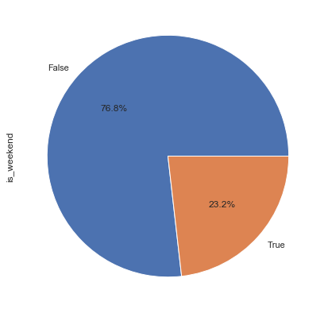

```python
plt.figure(figsize=(17,7))
df['is_weekend'].value_counts().plot.pie(autopct='%1.1f%%')
plt.show()
```

- **Surprisingly, Most of the customers are visiting on weekdays. Only 23% of customers visiting on weekends.**

**Distribution of numerical variables**

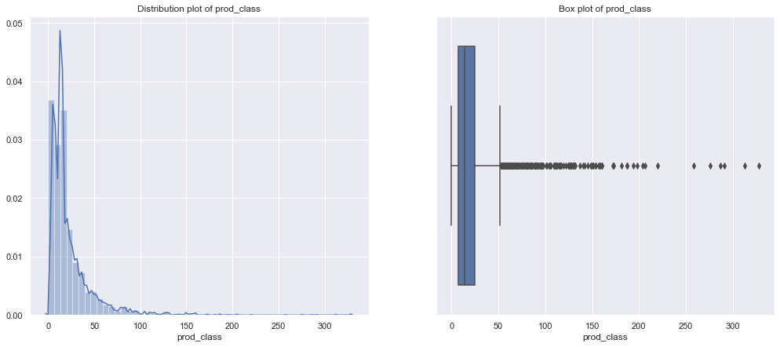

```
 Total Number of outliers in prod_class: 313
```

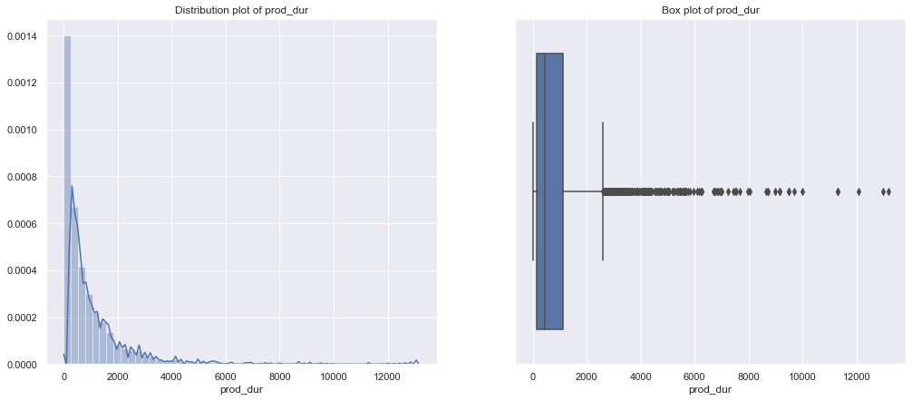

```
 Total Number of outliers in prod_dur: 275
```

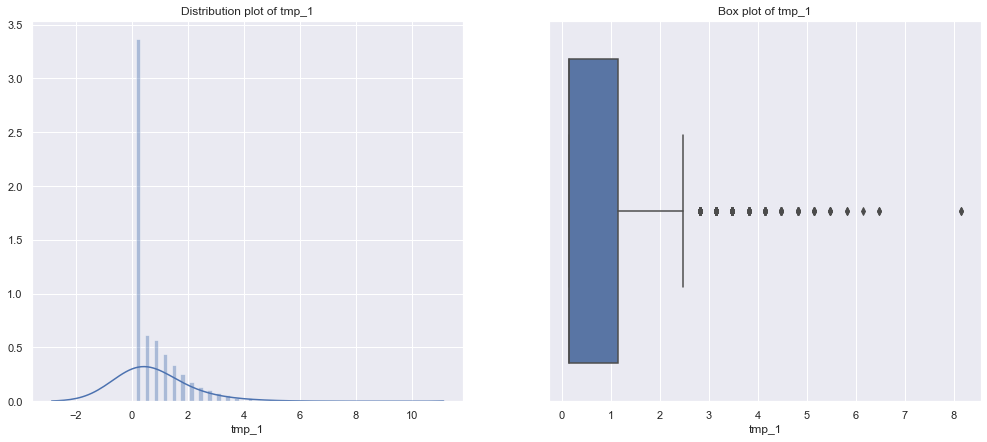

```
 Total Number of outliers in tmp_1: 220
```

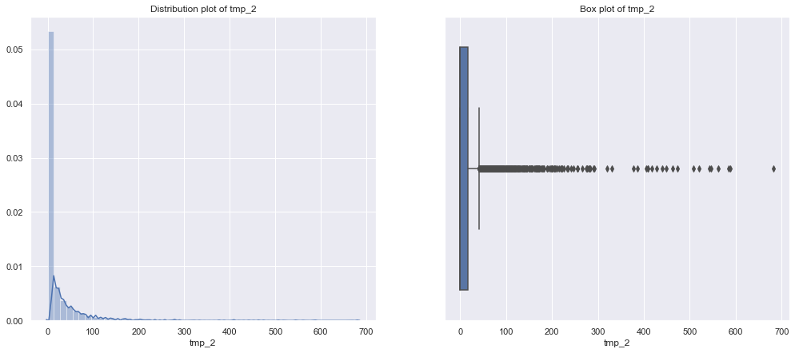

```
 Total Number of outliers in tmp_2: 513
```

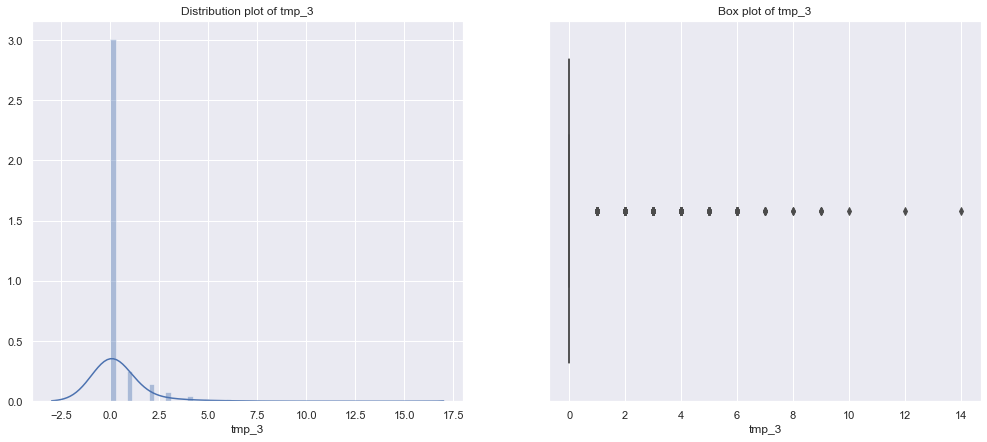

```
 Total Number of outliers in tmp_3: 603
```

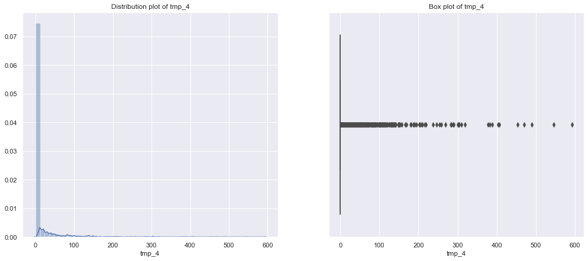

```
 Total Number of outliers in tmp_4: 596
```

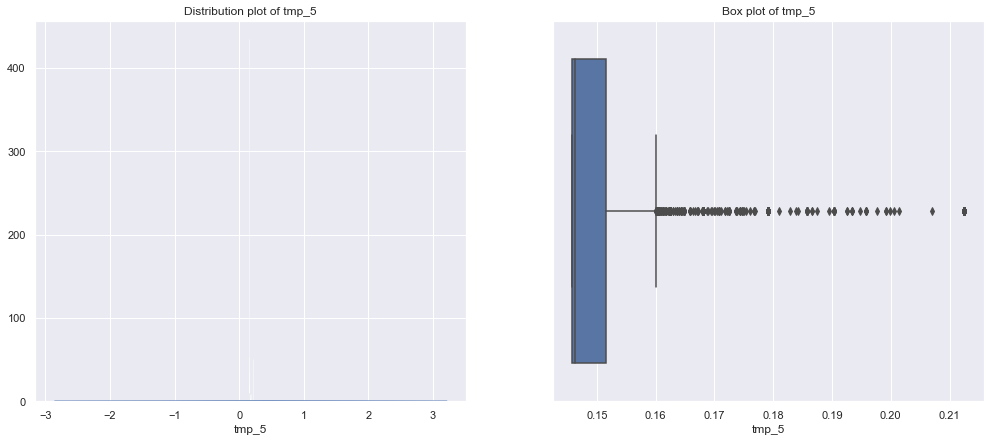

```
 Total Number of outliers in tmp_5: 543
```

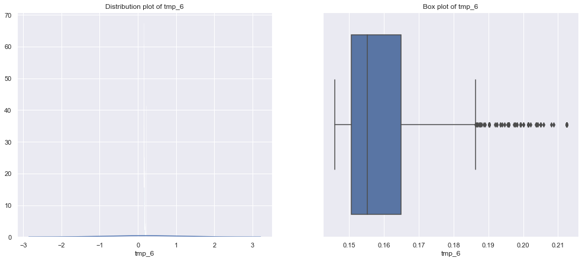

```
 Total Number of outliers in tmp_6: 400
```

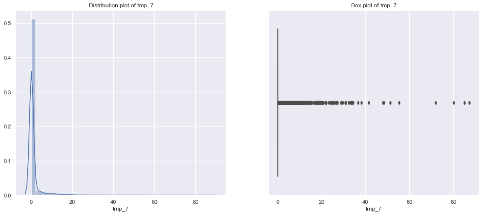

```
 Total Number of outliers in tmp_7: 492
```

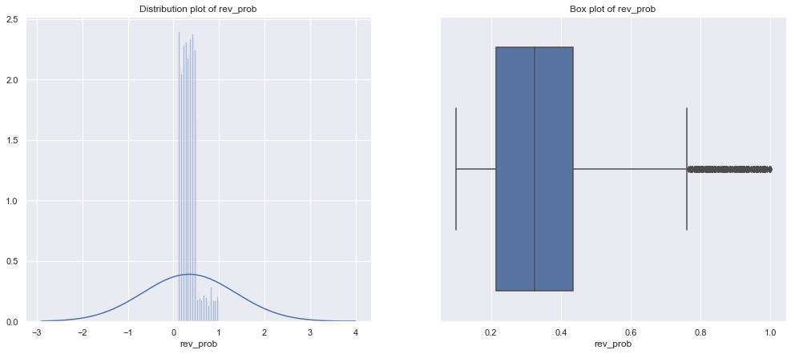

```
 Total Number of outliers in rev_prob: 174
```

```python
outlier_col=[]
col=['prod_class','prod_dur','tmp_1','tmp_2','tmp_3','tmp_4','tmp_5','tmp_6','tmp_7','rev_prob']
for i in col:
    f, axes = plt.subplots(1, 2, figsize=(17,7))
    sns.boxplot(x = i, data=df,  orient='h' , ax=axes[1])
    #sns.set(axis_bgcolor='k')
    sns.distplot(df[i],  ax=axes[0], kde_kws = {'bw' : 1})
    axes[0].set_title('Distribution plot of {}'.format(i))
    axes[1].set_title('Box plot of {}'.format(i))
    plt.show()
    #checking count of outliers.
    q25,q75=np.percentile(df[i],25),np.percentile(df[i],75)
    IQR=q75-q25
    Threshold=IQR*1.5
    lower,upper=q25-Threshold,q75+Threshold
    Outliers=[i for i in df[i] if i < lower or i > upper]
    if len(Outliers)>0:
        outlier_col.append(i)
    print('{} Total Number of outliers in {}: {}'.format('\033[1m',i,len(Outliers)))
```

- **As already discussed,data is hugely affected by outliers**

**Log Tranformation.**

```python
for i in col:
    df[i] = np.log(df[i])
```

```python
df = df.replace([np.inf, -np.inf, -0], 0)
```

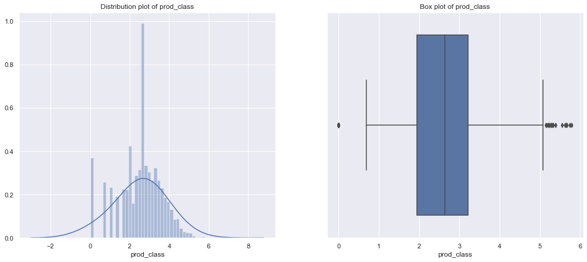

```
 Total Number of outliers in prod_class: 244
```

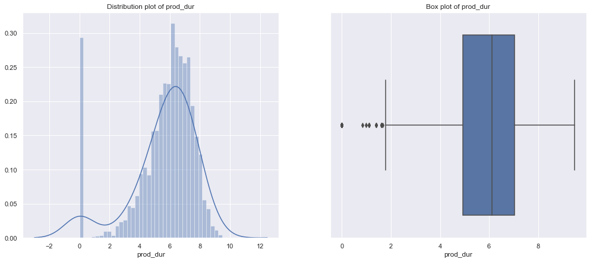

```
 Total Number of outliers in prod_dur: 313
```

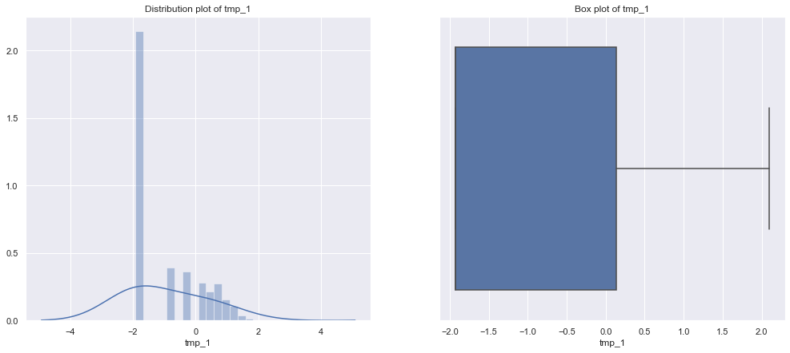

```
 Total Number of outliers in tmp_1: 0
```

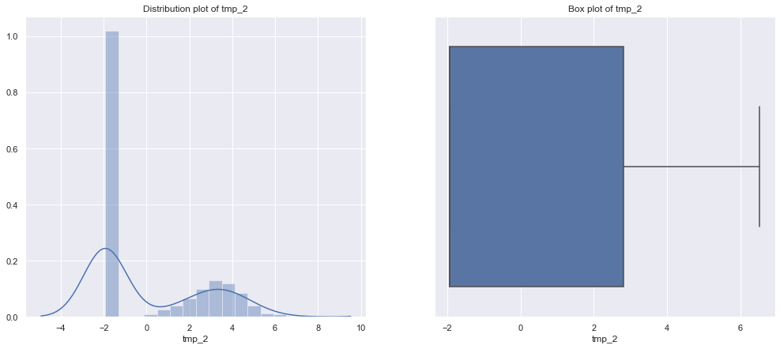

```
 Total Number of outliers in tmp_2: 0
```

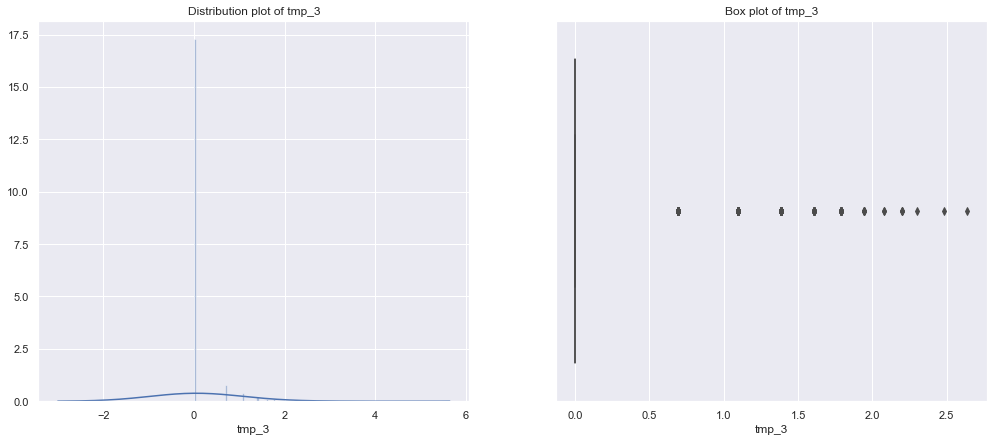

```
 Total Number of outliers in tmp_3: 334
```

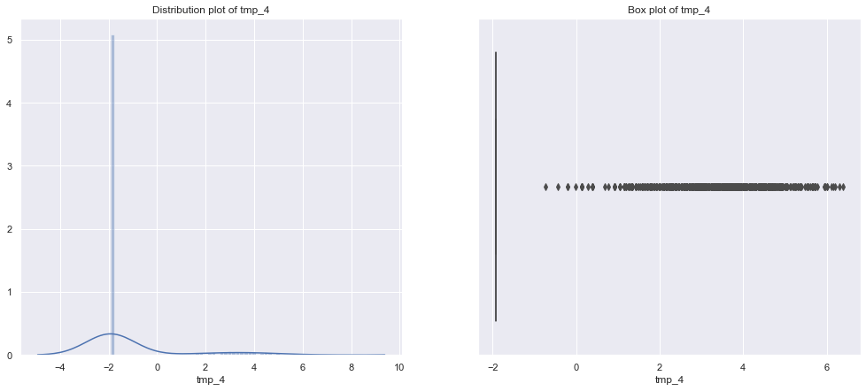

```
 Total Number of outliers in tmp_4: 596
```

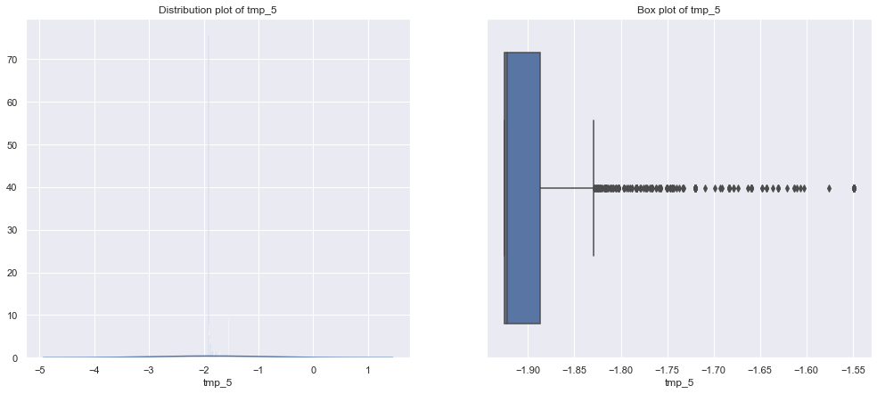

```
 Total Number of outliers in tmp_5: 532
```

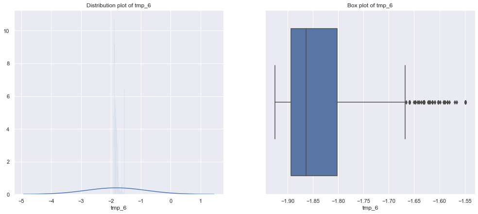

```
 Total Number of outliers in tmp_6: 384
```

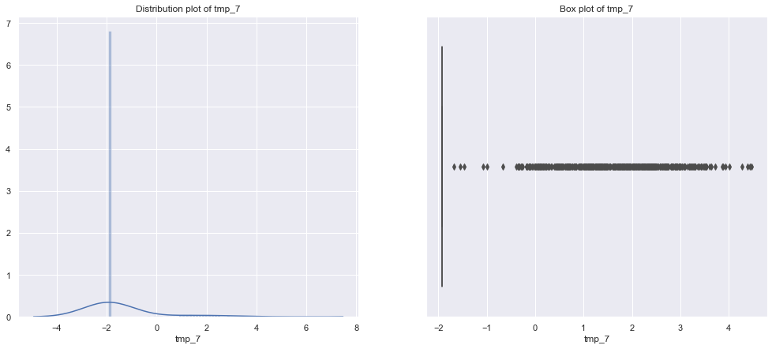

```
 Total Number of outliers in tmp_7: 492
```

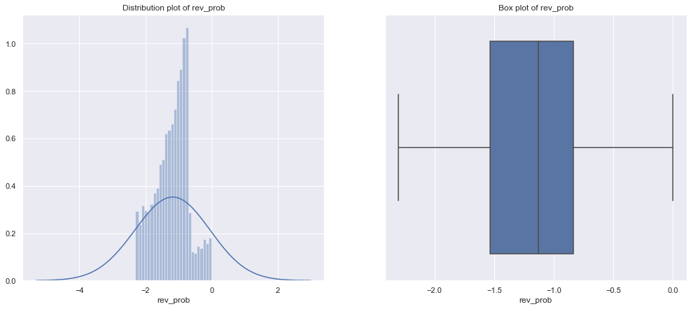

```
 Total Number of outliers in rev_prob: 0
```

```python
outlier_col=[]
col=['prod_class','prod_dur','tmp_1','tmp_2','tmp_3','tmp_4','tmp_5','tmp_6','tmp_7','rev_prob']
for i in col:
    f, axes = plt.subplots(1, 2, figsize=(17,7))
    sns.boxplot(x = i, data=df,  orient='h' , ax=axes[1])
    #sns.set(axis_bgcolor='k')
    sns.distplot(df[i],  ax=axes[0], kde_kws = {'bw' : 1})
    axes[0].set_title('Distribution plot of {}'.format(i))
    axes[1].set_title('Box plot of {}'.format(i))
    plt.show()
    #checking count of outliers.
    q25,q75=np.percentile(df[i],25),np.percentile(df[i],75)
    IQR=q75-q25
    Threshold=IQR*1.5
    lower,upper=q25-Threshold,q75+Threshold
    Outliers=[i for i in df[i] if i < lower or i > upper]
    if len(Outliers)>0:
        outlier_col.append(i)
    print('{} Total Number of outliers in {}: {}'.format('\033[1m',i,len(Outliers)))
```

**Few Outliers handled after Log transformation.**

- **Outliers:Whenever we are imputing values with mean/median the actual distribution of the data will change and that will produce few set of outliers according to that distribution. If we further remove this oultiers , we will lose variance information from data.**
- **It is evident from the graph that after log transformation few variables follows normal distribution.**

**Encoding vis_type**

```python
labelencoder=LabelEncoder()
df['vis_type']=labelencoder.fit_transform(df['vis_type'])
```

```python
df['is_special']=df['is_special'].astype('category')
df['os_class']=df['os_class'].astype('category')
df['region']=df['region'].astype('category')
df['traffic_class']=df['traffic_class'].astype('category')
df['vis_type']=df['vis_type'].astype('category')
df['is_weekend']=df['is_weekend'].astype('category')
df['int_brws']=df['int_brws'].astype('category')
```